# R Reference Guide

Johanna Ravenhurst

2022-12-14

# R Reference Guide

## Loading Data and Packages

R does not automatically load every extra package that has been installed. We must tell R that we want to load any packages that we need for a particular R script.

**library() and require() - the two functions for loading installed packages. They do almost the exact same thing.**

- library() will load a package again even if it was already loaded in the same R session. Use this if a package needed to be updated partway through a coding session.
- Save time by using require() because it does not re-load packages that are in the R memory already.

Here is an example of using require() to load the here package and library() to load the palmerpenguins packages:

```r
#load here package
require(here)
#load palmerpenguins package
library(palmerpenguins)
```

**Two functions for reading in a data set to create an R data.frame are here() and read.csv()**

read.csv() is a function which reads a csv data file and creates a R data.frame.

here() is useful because it always starts with the current Rproject folder (it does not change based on the working directory)

- Specify the nested subdirectories (folder names) in order (in quotes, comma in between subdirectory names)
- Specify the name of the file you wish to load (in quotes, include filetype extension)

This is an example of using here() and read.csv() to create a data.frame of the 2021 ginkgo data, which is stored in the “data” subdirectory of my RProject.

- Note that we assign the data.frame a name and save it to the R Environment using <- or = before the functions.

```r
#you can check the path to your RProject directory by just running the here() function
here()
```

```
## [1] "C:/Users/Johanna Ravenhurst/Documents/environmental_data"
```

```r
#data.frame called "ginkgo" created using here() and read.csv().
ginkgo <- read.csv(here("data", "ginkgo_data_2021.csv"))

#If you check the R Environment, there is a data.frame called "ginkgo" with 756 observations and 6 variables.
```

## Data Structures

**The combine function c() links elements into a vector (a 1-dimensional data structure consisting of 1 or more elements).**

```
All of the elements must be of the same type.
    I can’t combine character and numeric types in the same call to c()
```

Here’s two examples using numeric and character data types:

```r
## Create a vector of numbers:
num_vec  = c(1, 4, 8, 9, 13)

## Create a vector of characters:
char_vec = c("a", "fish", "data is cool")
```

I can show the contents of a vector by typing the name of the vector, or using the print() function.

```r
## Typing the name of the vector into the console prints the contents
num_vec
```

```
## [1]  1  4  8  9 13
```

```r
## The print() function accomplishes the same task:
print(char_vec)
```

```
## [1] "a"            "fish"         "data is cool"
```

I can use the class() function to learn the data type stored in the vector:

```r
class(char_vec)
```

```
## [1] "character"
```

```r
class(num_vec)
```

```
## [1] "numeric"
```

**length() - tells you the number of elements in a vector or other R object, or the number of columns in a data.frame.**

- length() also counts NA values
- for a string variable, it will count everything in quotes as 1

We can use this to calculate the length of the vectors we created above:

```r
#Repeat code as a reminder of the vectors we created
## Create a vector of numbers:
num_vec  = c(1, 4, 8, 9, 13)

## Create a vector of characters:
char_vec = c("a", "fish", "data is cool")

length(num_vec)
```

```
## [1] 5
```

```r
#answer = 5
length(char_vec)
```

```
## [1] 3
```

```r
#answer = 3
```

**matrix() - combines elements in to a matrix with a set number of rows/columns. The elements must be the same data type.**

matrix(elements to arrange, byrow = , nrow = ) - elements to arrange can be listed with c(), or include a range with a colon like 1:9 - byrow = TRUE fills the matrix by rows. byrow = FALSE fills by columns. - nrow gives the desired number of rows in the matrix

Here are two examples of creating a matrix:

```r
#matrix with numbers 1:12, arranged in 4 rows and filled by rows
matrix(1:12, byrow = TRUE, nrow = 4)
```

```
##      [,1] [,2] [,3]
## [1,]    1    2    3
## [2,]    4    5    6
## [3,]    7    8    9
## [4,]   10   11   12
```

```r
#matrix with days of the week, arranged in 2 rows and filled by columns
matrix(c("Monday", "Tuesday", "Wednesday", "Thursday", "Friday", "Saturday", "Sunday"), byrow = FALSE, nrow = 2)
```

```
##      [,1]      [,2]        [,3]       [,4]
## [1,] "Monday"  "Wednesday" "Friday"   "Sunday"
## [2,] "Tuesday" "Thursday"  "Saturday" "Monday"
```

When you specify a number of rows that does not fit the number of elements evenly, the matrix either cuts off the sequence or begins the sequence again to make the elements fit in the specified number of rows.

You can name the rows and columns of a matrix to make it easier to interpret the data. Do this using rownames() and colnames(). You can also use rowSums() to calculate the totals for each row. Here is an example of assigning row/column names to a matrix containing data from three plots with tick counts from two separate sample days and then calculating the row sums.

```r
#Tick count vectors:
puffers <- c(56, 43)
notch <- c(4, 87)
sugarloaf <- c(90, 5)

#Create the matrix
tick_counts <- matrix(c(puffers, notch, sugarloaf), nrow=3, byrow=TRUE)
totals <- rowSums(tick_counts)
#use cbind() to add a new vector to a matrix
all_tick_counts <- cbind(tick_counts, totals)

#Create vectors with plot names, sample day names
plots <- c("Puffers Pond", "The Notch", "Mt. Sugarloaf")
sample_days <- c("Day 1", "Day 2", "Total")

#Name the columns with sample_days
colnames(all_tick_counts) <- sample_days

#Name the rows with plot names
rownames(all_tick_counts) <- plots


all_tick_counts
```

```
##               Day 1 Day 2 Total
## Puffers Pond     56    43    99
## The Notch         4    87    91
## Mt. Sugarloaf    90     5    95
```

**data.frame() creates an R data frame, which contains different data types. Each row is an observation with values for different variables in columns**

- create a data.frame by listing the vectors to include. When creating your own data frame, all of the variables need to have the same number of elements

```r
#create 3 vectors for the data.frame "tickdata"
day_1_ticks <- c(3, 4, 67, 87)
day_2_ticks <- c(56, 7, 98, 12)
plots <- c("Puffers Pond", "The Notch", "Mt. Sugarloaf", "Puffers Pond")

#create the data.frame "tickdata" by combining the three vectors
tickdata <- data.frame(plots, day_1_ticks, day_2_ticks)
tickdata
```

```
##           plots day_1_ticks day_2_ticks
## 1  Puffers Pond           3          56
## 2     The Notch           4           7
## 3 Mt. Sugarloaf          67          98
## 4  Puffers Pond          87          12
```

When working with a large data.frame, it’s useful to use head() to view the first few lines of data or tail() to view the last few lines of data.

```r
#view first few lines and last few lines of ginkgo dataset
head(ginkgo)
```

```
##   site_id seeds_present max_width max_depth notch_depth petiole_length
## 1    1896         FALSE        64        42           2             37
## 2    1896         FALSE        72        54           3             77
## 3    1896         FALSE        77        54           5             90
## 4    1896         FALSE        63        49           5             74
## 5    1896         FALSE        52        51           5             85
## 6    1896         FALSE        57        46           5             71
```

```r
tail(ginkgo)
```

```
##     site_id seeds_present max_width max_depth notch_depth petiole_length
## 751   12982         FALSE       101        60          23             49
## 752   12982         FALSE        72        73          29             38
## 753   12982         FALSE        59        63          29             22
## 754   12982         FALSE        78        85          32             20
## 755   12982         FALSE        87        70          32             45
## 756   12982         FALSE        68        77          47             24
```

It’s also useful to check the structure of your data.frame using str().The output includes: - # observations - # variables - list of variable names - data type of variables - first observations of variables

```r
#view structure of ginkgo data frame
str(ginkgo)
```

```
## 'data.frame':    756 obs. of  6 variables:
##  $ site_id       : int  1896 1896 1896 1896 1896 1896 1896 1896 1896 1896 ...
##  $ seeds_present : logi  FALSE FALSE FALSE FALSE FALSE FALSE ...
##  $ max_width     : num  64 72 77 63 52 57 54 63 85 89 ...
##  $ max_depth     : int  42 54 54 49 51 46 39 40 45 60 ...
##  $ notch_depth   : num  2 3 5 5 5 5 5 6 6 6 ...
##  $ petiole_length: num  37 77 90 74 85 71 50 48 41 95 ...
```

**nrow() - to count the number of observations/rows for a variable**

- can be used with a vector, matrix, or data.frame

```r
#find the number of rows in the ginkgo data.frame
nrow(ginkgo)
```

```
## [1] 756
```

**ncol() - to count the number of columns**

- can be used with a vector, matrix, or data.frame

```r
#find the number of columns in the ginkgo data.frame
ncol(ginkgo)
```

```
## [1] 6
```

**dim() gives the size of the R object - number of rows/columns or number of elements**

```r
#find the dimensions of the ginkgo data.frame
dim(ginkgo) #gives number of rows and number of columns for the data.frame
```

```
## [1] 756   6
```

## Subsetting

**Subset a column from a data.frame by name with $**

```r
#select the notch.depth column in the ginkgo data and save as notch_ginkgo
notch_ginkgo <- ginkgo$notch_depth
```

**Subset by position with [] to select a specific element within a vector, matrix, or data.frame** You can specify the element to select by using a number (ie to select the first element just enter 1), a list of two numbers (to specify row, column where element is located), or the name of the element in quotes.

Here are some examples:

```r
#select first row of the ginkgo data
ginkgo[1, ]
```

```
##   site_id seeds_present max_width max_depth notch_depth petiole_length
## 1    1896         FALSE        64        42           2             37
```

```r
#select the element in row 2, column 3
ginkgo[2, 3]
```

```
## [1] 72
```

```r
#select the 3rd column of the ginkgo data
ginkgo[ , 3]
```

```
##   [1]  64.0  72.0  77.0  63.0  52.0  57.0  54.0  63.0  85.0  89.0  74.0 102.0
##  [13]  75.0  62.0 103.0  92.0  74.0  68.0  84.0  88.0  70.0  41.0  70.0  38.0
##  [25]  75.0  67.0  72.0  61.0  68.0  54.0  44.0  27.0  42.0  49.0  75.0  66.0
##  [37]  75.0  72.0  81.0  79.0  68.0  82.0  76.0  69.0  64.0  65.0  82.0  75.0
##  [49]  60.0  87.0  57.0  76.0  63.0  88.0  70.0  40.0  70.0  72.0  75.0  82.0
##  [61]  85.0  66.0  75.0  76.0  60.0  85.0  82.0  78.0  53.0  55.0  38.0  78.0
##  [73]  58.0  58.0  53.0  53.0  55.0  40.0  35.0  54.0  54.0  38.0  44.0  53.0
##  [85]  42.0  49.0  45.0  42.0  34.0  36.0  39.0  16.0  61.0  55.0  72.0  69.0
##  [97]  75.0  72.0  61.0  82.0  66.0  84.0  63.0  78.0  89.0  68.0  73.0  70.0
## [109]  71.0  59.0  70.0  78.0  62.0  78.0  73.0  79.0  72.0  74.0  73.0  70.0
## [121]  72.0  70.0  53.0  65.0  95.0  95.0  47.0  46.0  82.0  81.0  82.0  68.0
## [133]  46.0  84.0  52.0  73.0  85.0  88.0  98.0  86.0  67.0  91.0  92.0  97.0
## [145] 100.0  99.0  55.0  90.0  52.0 111.0  73.0  90.0  92.0  64.0  68.0  53.0
## [157]  97.0 100.0  90.0  89.0  59.0  97.0  76.0  85.0  90.0  67.0  89.0  71.0
## [169]  64.0  91.0 106.0  89.0  80.0  88.0 108.0  86.0  72.0 114.0 104.0  78.0
```

[output cut: 48 more lines]

```r
#select the first 5 elements of the column notch_depth
ginkgo[1:5, "notch_depth"]
```

```
## [1] 2 3 5 5 5
```

**subset() selects from a data.frame based on the conditions you specify, such as belonging to a certain level of a factor (such as a species) or having a numerical value greater than 0**

- the first argument is the name of the dataset
- the second argument specifies the conditions that must be met for the data to be included

```r
#Extract the measurements for only the Adelie penguins from the penguins dataset
dat_adelie = subset(penguins, species == "Adelie")
```

## Numerical Data Exploration

**summary() provides summary statistics for the vector. If an entire data.frame is entered, the output includes a summary of every column in the data frame.**

- character vectors = count of observations in each level, number of NA’s
- numerical vectors = min, max, median, mean, 1st/3rd quartile, number of NA’s
- syntax note: use data.frame$vectorname to specify a certain variable

```r
#Summary statistics for ginkgo data.frame
summary(ginkgo)
```

```
##     site_id      seeds_present     max_width        max_depth
##  Min.   : 1896   Mode :logical   Min.   : 16.00   Min.   : 19.00
##  1st Qu.: 3703   FALSE:636       1st Qu.: 63.00   1st Qu.: 43.00
##  Median : 6066   TRUE :120       Median : 74.00   Median : 51.00
##  Mean   : 6079                   Mean   : 74.34   Mean   : 58.51
##  3rd Qu.: 7206                   3rd Qu.: 85.00   3rd Qu.: 66.00
##  Max.   :12982                   Max.   :130.00   Max.   :145.00
##
##   notch_depth    petiole_length
##  Min.   : 0.00   Min.   :  8.00
##  1st Qu.: 0.00   1st Qu.: 34.00
##  Median : 0.00   Median : 47.00
##  Mean   : 2.99   Mean   : 48.25
##  3rd Qu.: 4.00   3rd Qu.: 60.00
##  Max.   :49.00   Max.   :113.00
##                  NA's   :4
```

**mean() calculates the average of a the elements in a given vector**

- use the na.rm argument to eliminate issues with missing data. na.rm = TRUE removes NA values before calculating the mean.

```r
#calculate the mean notch_depth for the ginkgo dataset
mean(ginkgo$notch_depth)
```

```
## [1] 2.990079
```

```r
#calculate the mean petiole_length for the ginkgo dataset
mean(ginkgo$petiole_length)
```

```
## [1] NA
```

```r
#answer = NA because we need to tell R to remove NA values before calculating the mean

#try again using the na.rm argument
mean(ginkgo$petiole_length, na.rm = TRUE)
```

```
## [1] 48.2515
```

**sd() calculates the standard deviation of a vector**

```r
#standard deviation of notch_depth from ginkgo data
sd(ginkgo$notch_depth)
```

```
## [1] 5.982555
```

## Graphical Data Exploration

**plot() is used to plot R objects.** The default is a simple scatter plot, but you can specify different types of plots using type argument. You can use points() to add additional points and curve() to add a function of a line to the plot if needed.

There are many arguments to enhance the plot and convey all of the important information.

Example scatterplot using ginkgo data:

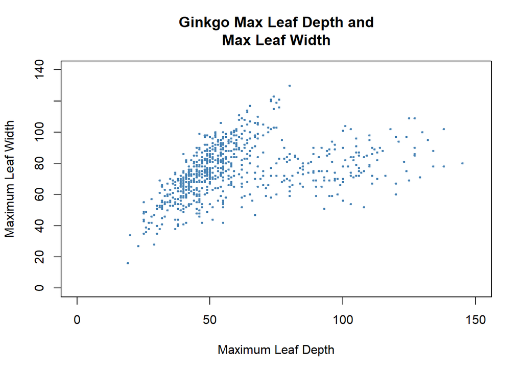

```r
#Scatterplot from ginkgo data
#x = max leaf depth
#y = max leaf width

plot(ginkgo$max_depth, ginkgo$max_width,
     main = "Ginkgo Max Leaf Depth and\nMax Leaf Width",
     xlab = "Maximum Leaf Depth",
     ylab = "Maximum Leaf Width",
     cex = 0.5,
     pch = 20,
     col = "steelblue",
     xlim = c(0, 150),
     ylim = c(0, 140))
```

**hist() creates a histogram, which is a bar chart showing the frequency of observations for each x value**

- breaks = is an argument used to specify the number of breaks or bars in the histogram. This is helpful when the bins R chooses aren’t appropriate for your data. Some options to try:
  - “breaks = 0:7” instead of “breaks = 7” to force R to use the number of bins desired.
  - If 0 and 1 are lumped together in one bin, try subtracting 0.5: “breaks = 0:7 - .5”.
  - use c() to specify the exact break points for the bins (see example below)

Example histogram of penguin flipper lengths:

```r
#use summary to examine min/max and decide what to do with breaks argument
summary(penguins$flipper_length_mm)
```

```
##    Min. 1st Qu.  Median    Mean 3rd Qu.    Max.    NA's
##   172.0   190.0   197.0   200.9   213.0   231.0       2
```

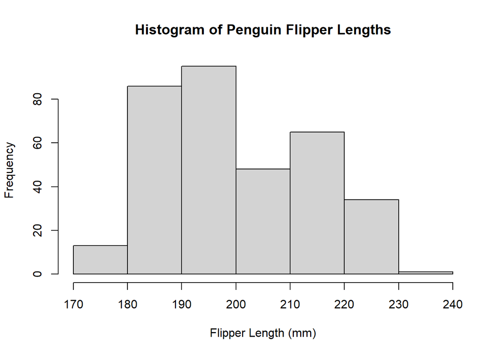

```r
#create a histogram of penguin flipper lengths with 7 bins
hist(penguins$flipper_length_mm,
     main = "Histogram of Penguin Flipper Lengths",
     xlab = "Flipper Length (mm)",
     breaks = c(170, 180, 190, 200, 210, 220, 230, 240))
```

**boxplot() creates a basic boxplot**

- syntax note: use data.frame$vectorname to specify a certain variable or use formula notation “y ~ x” to specify two variables to compare from a given data frame.
- The response or y variable must be continuous
- The predictor variable must be categorical.

A simple boxplot example using the ginkgo data:

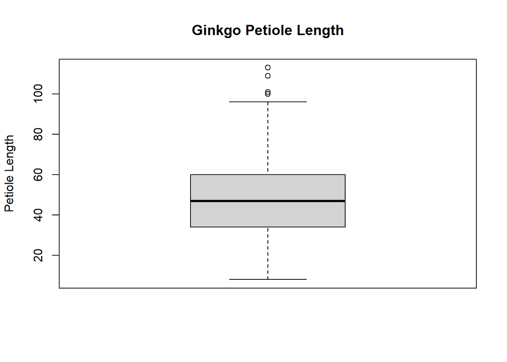

```r
#boxplot of ginkgo petiole lengths
boxplot(ginkgo$petiole_length,
        main = "Ginkgo Petiole Length",
        ylab = "Petiole Length")
```

Conditional boxplots are useful for examining how a second or third variable might be impacting the y variable of interest.

An example conditional boxplot using the ginkgo data for max_depth conditioned on the seeds_present column:

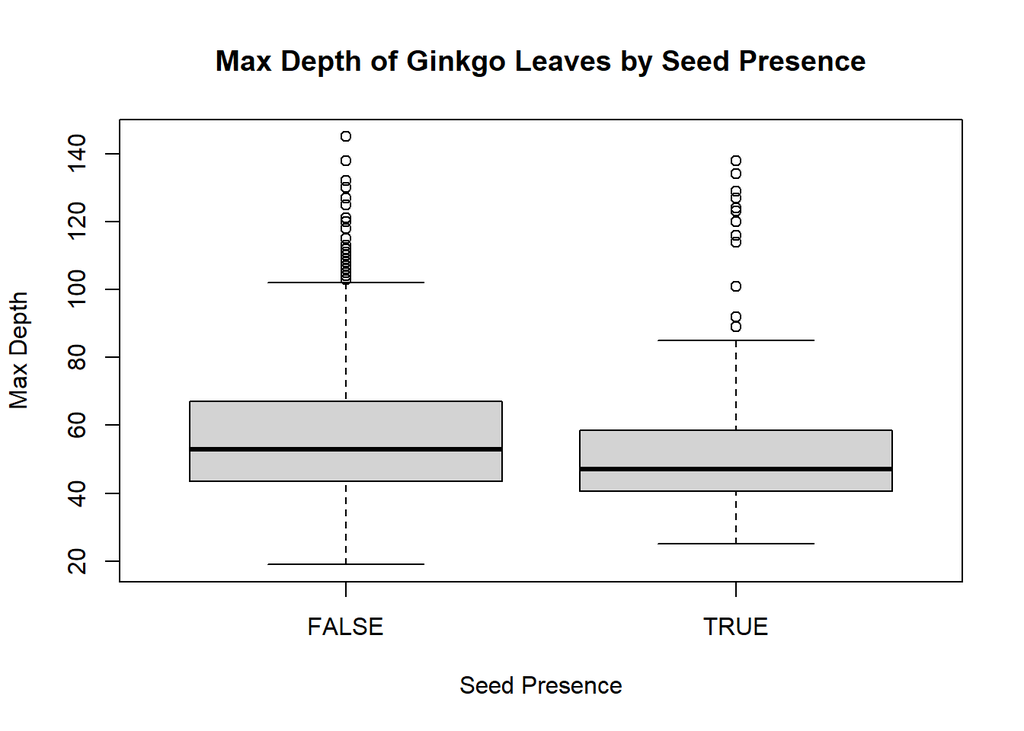

```r
#boxplot conditioned on continuous variable max_depth conditioned on seeds_present column in ginkgo data frame

boxplot(
    max_depth ~ seeds_present, data = ginkgo,
    main = "Max Depth of Ginkgo Leaves by Seed Presence",
    ylab = "Max Depth",
    xlab = "Seed Presence")
```

**par() is useful for specifying parameters for a plot/graph or group of plots/graphs. It’s helpful for arranging multiple plots in to a figure with a fixed number of rows/columns**

- mfrow is a vector c(numberrows, numbercolumns) and is used to make a figure with a set of plots or graphs arranged in to the specified number of rows/columns.
- use par() before a set of code for a given plot

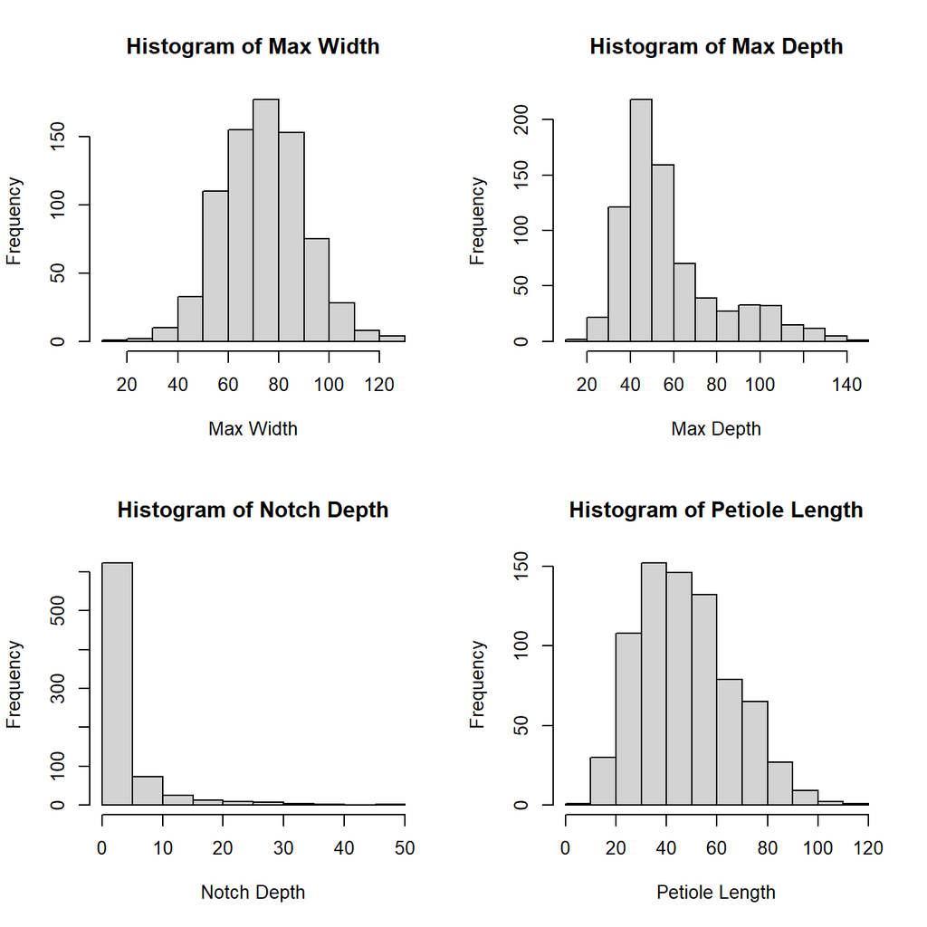

```r
#Use code chunk options to adjust the figure height/width

#Use par() and mfrow = C(2,2) to arrange four different histograms in a 2 by 2 grid

#4 histograms of ginkgo data
par(mfrow = c(2,2))
{
hist(ginkgo$max_width,
     main = "Histogram of Max Width",
     xlab = "Max Width")
hist(ginkgo$max_depth,
     main = "Histogram of Max Depth",
     xlab = "Max Depth")
hist(ginkgo$notch_depth,
     main = "Histogram of Notch Depth",
     xlab = "Notch Depth")
hist(ginkgo$petiole_length,
     main = "Histogram of Petiole Length",
     xlab = "Petiole Length")
}
```